# Data Science Specialization Capstone Project Week 2

Szymon Lipiński

10/28/2019

# Data Science Specialization Capstone Project Week 2

## Load Needed Libraries

```r
library(knitr)
library(tidyverse)
library(tm)
library(dplyr)
library(wordcloud)
library(tidytext)
```

## Downloading and Loading Data

The data set file has been downloaded from https://d396qusza40orc.cloudfront.net/dsscapstone/dataset/Coursera-SwiftKey.zip. Then it has been saved to `../data/Coursera-SwiftKey.zip` and unpacked. The zip file contains just one directory `final`, so all the English files are stored in `../data/final/en_US`.

```r
basicDir <- "../data/final/en_US/"
twitterFilePath <- paste(basicDir, "en_US.twitter.txt", sep = "")
blogsFilePath <- paste(basicDir, "en_US.blogs.txt", sep = "")
newsFilePath <- paste(basicDir, "en_US.news.txt", sep = "")
```

Reading the files content to variables:

```r
twitterData <- readLines(twitterFilePath, encoding="UTF-8", skipNul = TRUE)
blogsData <- readLines(blogsFilePath, encoding="UTF-8", skipNul = TRUE)
newsData <- readLines(newsFilePath, encoding="UTF-8", skipNul = TRUE)
```

## Basic Data Summary

Let’s find some basic information about the data:

```r
data <- list(twitterData, blogsData, newsData)
words <- sapply(data, function(x){lengths(strsplit(x, " "))})
twitterWords = lengths(strsplit(twitterData, " "))
blogsWords = lengths(strsplit(blogsData, " "))
newsWords = lengths(strsplit(newsData, " "))

rm(twitterData)
rm(newsData)
rm(blogsData)
gc()
```

```
##            used  (Mb) gc trigger   (Mb)  max used   (Mb)
## Ncells  6109385 326.3   18512482  988.7  13967058  746.0
## Vcells 96360685 735.2  212838740 1623.9 212838739 1623.9
```

```r
kable(data.frame(
  DataSources = c("Twitter", "Blogs", "News"),
  RowCount = format(sapply(data, function(x){length(x)}), big.mark = ","),
  DataSize = sapply(data, function(x){format(object.size(x),"MiB")})
))
```

| DataSources | RowCount | DataSize |
| --- | --- | --- |
| Twitter | 2,360,148 | 319 MiB |
| Blogs | 899,288 | 255.4 MiB |
| News | 1,010,242 | 257.3 MiB |

```r
kable(data.frame(
  DataSources = c("Twitter", "Blogs", "News"),
  MinCharactersInEntry = format(sapply(data, function(x){min(nchar(x))}), big.mark = ","),
  AverageCharactersInEntry = format(sapply(data, function(x){mean(nchar(x))}), big.mark = ","),
  MaxCharactersInEntry = format(sapply(data, function(x){max(nchar(x))}), big.mark = ",")
))
```

| DataSources | MinCharactersInEntry | AverageCharactersInEntry | MaxCharactersInEntry |
| --- | --- | --- | --- |
| Twitter | 2 | 68.68054 | 140 |
| Blogs | 1 | 229.98695 | 40,833 |
| News | 1 | 201.16285 | 11,384 |

```r
kable(data.frame(
  DataSources = c("Twitter", "Blogs", "News"),
  MinWordsInEntry = format(sapply(words, function(x){min(x)}), big.mark = ","),
  AverageWordsInEntry = format(sapply(words, function(x){mean(x)}), big.mark = ","),
  MaxWordsInEntry = format(sapply(words, function(x){max(x)}), big.mark = ",")
))
```

| DataSources | MinWordsInEntry | AverageWordsInEntry | MaxWordsInEntry |
| --- | --- | --- | --- |
| Twitter | 1 | 12.86936 | 47 |
| Blogs | 1 | 41.51521 | 6,630 |
| News | 1 | 34.02406 | 1,792 |

```r
rm(words)
rm(twitterWords)
rm(blogsWords)
rm(newsWords)
gc()
```

```
##            used  (Mb) gc trigger   (Mb)  max used   (Mb)
## Ncells  6117823 326.8   18512482  988.7  13967058  746.0
## Vcells 92112046 702.8  300428013 2292.1 299273590 2283.3
```

## Data Cleaning

Because of the size of the data, there will chosen a small subset to create the corpus used for further analysis.

```r
data <- unlist(data)
sampleSize <- 10/100 # sample size in percents

indices <- function(){sample(seq_len(length(data)), length(data)*sampleSize)}
```

```r
indices <- indices()
sampleData <- data[indices]
```

```r
corpus <- Corpus(VectorSource(unlist(sampleData, use.names = FALSE)),
                 readerControl = list(reader = readPlain, language = "en"))

# Remove non-ASCII characters
corpus <- Corpus(VectorSource(sapply(corpus, function(row) iconv(row, "latin1", "ASCII", sub = ""))))
```

Let’s make the corpus and clean the data a little bit:

```r
corpus <- corpus %>%
  tm_map(removePunctuation) %>% # Remove punctuation mar
  tm_map(removeNumbers) %>% # Remove number
  tm_map(stripWhitespace) %>% # Strip extra whitespace from a text document. Multiple whitespace characters are collapsed to asingle blank.
  tm_map(content_transformer(tolower)) %>% # make lower case
  tm_map(PlainTextDocument) # Create plain text documents.

corpusNoStopWords <- corpus %>%
  tm_map(removeWords, stopwords("english"))

corpusDF <- data.frame(unlist(as.list(as.list(corpus))), stringsAsFactors = FALSE)

corpusDFNoSW <- data.frame(unlist(as.list(as.list(corpusNoStopWords))), stringsAsFactors = FALSE)

colnames(corpusDF) <- c("text")
colnames(corpusDFNoSW) <- c("text")

corpusDF <- corpusDF %>% dplyr::filter(!(text == " "))
```

The whole data size is 831.5 MiB.

With the sample size of 10%, the size of the plain text corpus with all the words is: 80.4 MiB and without the stop words is: 98.5 MiB

The code is prepared for using smaller sample, however, using a huge one is quite fine for my computer.

## N-grams

```r
buildNGrams <- function(data, n) {
  startTime <- Sys.time()
  result <- data %>%
    unnest_tokens(ngram, text, token = "ngrams", n = n) %>%
    dplyr::count(ngram, sort = TRUE)
  elapsedTime <- Sys.time() - startTime
  list(result, elapsedTime)
}
```

```r
monogramsOutput <- buildNGrams(corpusDF, 1)
monograms <- monogramsOutput[[1]]
monogramsTime <- monogramsOutput[[2]]
monograms
```

```
## # A tibble: 215,150 x 2
##    ngram      n
##    <chr>  <int>
##  1 the   475558
##  2 to    276523
##  3 and   240580
##  4 a     238613
##  5 of    200715
##  6 i     164535
##  7 in    164489
##  8 for   110279
##  9 is    107131
## 10 that  103672
## # … with 215,140 more rows
```

```r
bigramsOutput <- buildNGrams(corpusDF, 2)
bigrams <- bigramsOutput[[1]]
bigramsTime <- bigramsOutput[[2]]
```

```r
trigramsOutput <- buildNGrams(corpusDF, 3)
trigrams <- trigramsOutput[[1]]
trigramsTime <- trigramsOutput[[2]]
```

```r
quadgramsOutput <- buildNGrams(corpusDF, 4)
quadgrams <- quadgramsOutput[[1]]
quadgramsTime <- quadgramsOutput[[2]]
```

Calculated 215,150 monograms in 24s.

Calculated 2,869,673 bigrams in 56s.

Calculated 6,938,329 trigrams in 2s.

Calculated 9,131,520 quadgrams in 3s.

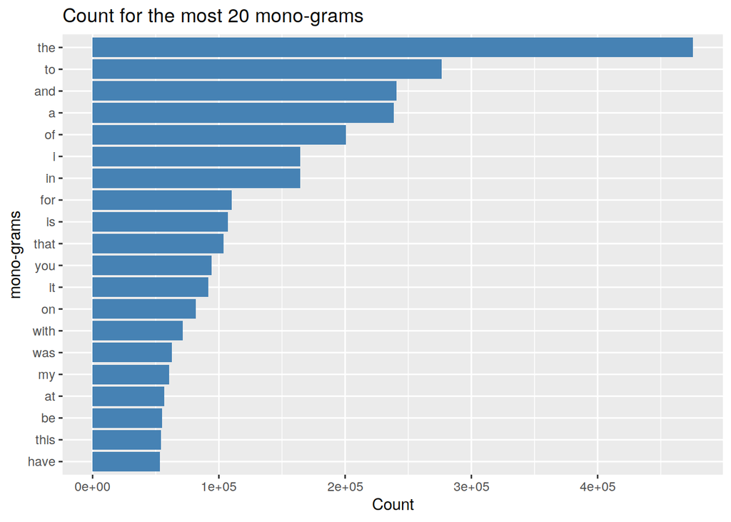

```r
nTopNGrams <- 20

pl1 <- ggplot(data = monograms[1:nTopNGrams,], aes(x = reorder(ngram, n), y = n)) +
  geom_bar(stat = "identity", fill = "steelblue") +
  labs(x = "mono-grams", y = "Count", title = "Count for the most 20 mono-grams") +
  coord_flip()

pl2 <- ggplot(data = bigrams[1:nTopNGrams,], aes(x = reorder(ngram, n), y = n)) +
  geom_bar(stat = "identity", fill = "steelblue") +
  labs(x = "bi-grams", y = "Count", title = "Count for the most 20 bi-grams") +
  coord_flip()

pl3 <- ggplot(data = trigrams[1:nTopNGrams,], aes(x = reorder(ngram, n), y = n)) +
  geom_bar(stat = "identity", fill = "steelblue") +
  labs(x = "tri-grams", y = "Count", title = "Count for the most 20 tri-grams") +
  coord_flip()

pl4 <- ggplot(data = quadgrams[1:nTopNGrams,], aes(x = reorder(ngram, n), y = n)) +
  geom_bar(stat = "identity", fill = "steelblue") +
  labs(x = "quad-grams", y = "Count", title = "Count for the most 20 quad-grams") +
  coord_flip()

#library(gridExtra)
#grid.arrange(pl1, pl2, pl3, pl4, nrow = 2, ncol = 2)

pl1
```

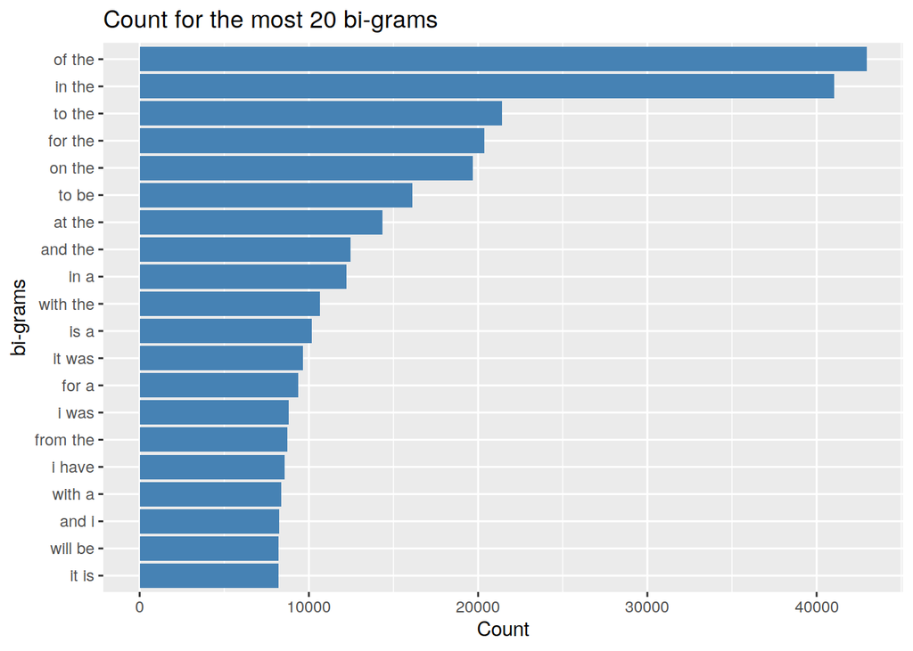

```r
pl2
```

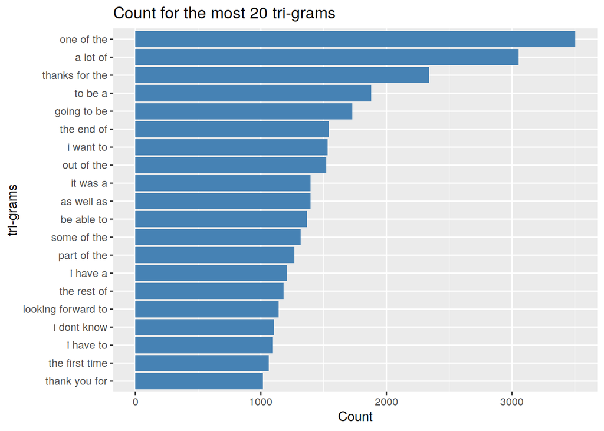

```r
pl3
```

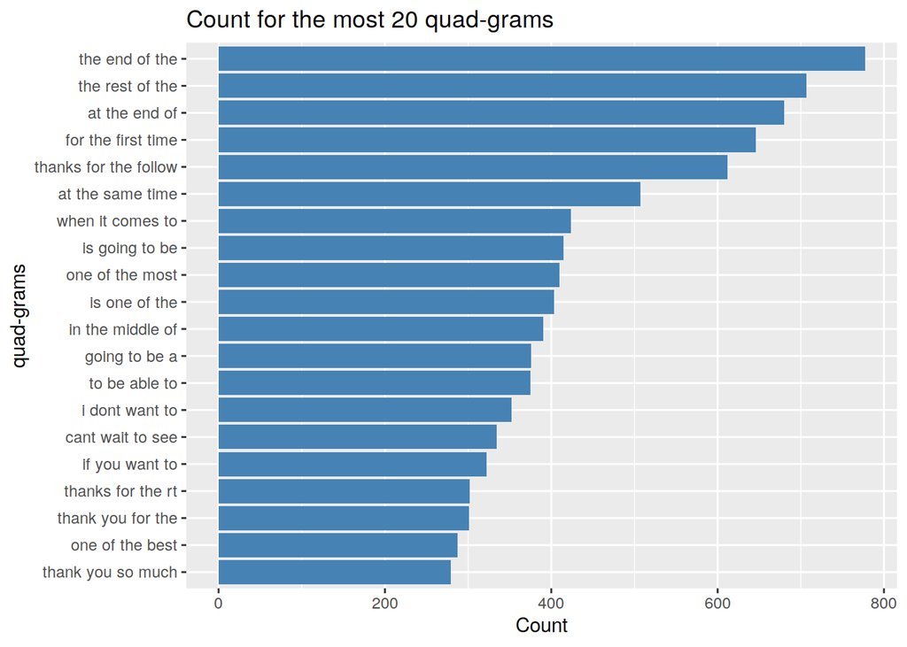

```r
pl4
```

## Further Steps

### The Prediction Algorithm

My algorithm will be using the n-gram model built in the previous step. For each provided word, or a couple of words, I will be able to search the n-gram model to predict the words with the highest probability, in this case, with the highest count from the model.

It is possible to use bigrams for this, but also trigrams, or quadgrams. I will need to see what’s the best way to do it.

### The Shiny App

The UI will be built using the Shiny library. It will allow users to enter a phrase, then it will suggest the next most likely word.